# Gaussian Component-wise Boosting

Luca Messerschmidt

Bjarne Herbst

Benedict B. Schnitzler

# Overview

This vignette introduces the main workflow for fitting **Gaussian location-scale regression models** with component-wise gradient boosting using **asp26boost**.

Unlike conventional regression models, which typically model only the conditional mean of a response, distributional regression allows several parameters of the response distribution to depend on covariates. For a Gaussian response, this means that both the conditional mean and the conditional standard deviation can be modeled:

$$Y_i \mid \mathbf{x}_i
\sim
\mathcal{N}(\mu_i, \sigma_i^2).$$

In `asp26boost`, the two distributional parameters are represented by separate predictors,

$$\mu_i = \eta_{\mu,i},
\qquad
\log(\sigma_i) = \eta_{\sigma,i},$$

so that the fitted standard deviation is always positive.

Component-wise boosting estimates these predictors iteratively. At each update, the current negative gradient of the joint Gaussian negative log-likelihood is calculated. Candidate base learners are then fitted to this gradient, and the best candidate is selected. Only the selected learner is added to the corresponding predictor, multiplied by a learning-rate parameter.

This combination of small updates and early stopping provides both regularization and variable selection. Covariates that are never selected remain absent from the corresponding predictor, while selected effects are shrunken toward their initial values.

`asp26boost` supports:

- separate predictor matrices for the location and scale submodels;
- linear, penalized spline, or automatically selected base learners;
- cyclic and noncyclic parameter-update schedules;
- fixed stopping iterations;
- patience-based internal early stopping;
- cross-validation for selecting the stopping iteration; and
- grid search over stopping iterations, learning rates, and learner types.

The following sections demonstrate these features using a simulated heteroskedastic Gaussian regression problem.

# Installation

```r
library(asp26boost)
```

# Simulated Gaussian Location-Scale Data

We begin by generating a dataset in which different predictors affect the conditional mean and conditional scale.

```r
set.seed(27092001)

n <- 1000
p <- 10

X <- matrix(
  rnorm(n * p),
  nrow = n,
  ncol = p
)

colnames(X) <- paste0("x", seq_len(p))

# Location model
beta_mu <- c(
  2, -1.5, 1,
  rep(0, p - 3)
)

mu <- as.numeric(X %*% beta_mu)

# Scale model
# The scale effects are specified on the log(sigma) scale.
beta_sigma <- c(
  0, 0, 0,
  0.5, -0.4, 0.3,
  rep(0, p - 6)
)

log_sigma <- as.numeric(X %*% beta_sigma)
sigma <- exp(log_sigma)

# Gaussian response
y <- rnorm(
  n,
  mean = mu,
  sd = sigma
)

sample_data <- data.frame(
  y = y,
  X
)

head(sample_data)
>           y         x1         x2          x3         x4           x5
> 1  2.299111 -0.4261948 -1.1171738  0.48469532  1.2131425 -0.336170941
> 2 -0.502648 -0.7131972  0.4245545  0.44002122 -0.8269670 -0.942629273
> 3 -5.100697 -1.8385995  0.3599087 -0.22333695 -0.4738789 -0.996149133
> 4 -3.647504  0.8625711  1.5398105 -0.07525713  1.4213003 -0.003867292
> 5 -3.617573 -1.0810953  1.3918728  0.35499283 -0.5583812  0.978657121
> 6 -4.111268 -1.7623401 -0.8189664 -1.73188716 -1.5627475 -0.983039525
>           x6          x7         x8         x9        x10
> 1 -1.2355394  0.70395175  2.1222730 -1.7657446  0.4977308
> 2  0.8983855 -1.19335497 -0.9879921  0.2926119  0.8580337
> 3 -2.0669550 -0.65491769  0.5644572  0.5134706  0.3168015
> 4  0.4912211  0.22194407  0.7515952 -1.4363766  0.8185884
> 5 -0.7280939  0.04176014  0.3786812 -0.3892265 -1.1157866
> 6 -0.8300621 -2.22611065  0.9980038  0.3107517 -0.5029159
```

The data-generating mechanism contains three signal variables for the location model (`x1`, `x2`, `x3`) and three different signal variables for the scale model (`x4`, `x5`, `x6`). The remaining variables are noise.

The scale model is defined on the logarithmic scale,

$$\log(\sigma_i)
=
0.5x_{i4}
-0.4x_{i5}
+0.3x_{i6},$$

which ensures that the resulting standard deviation

$$\sigma_i = \exp\{\log(\sigma_i)\}$$

is positive.

This setup illustrates an important feature of distributional regression: a predictor can influence the variability of the response without affecting its conditional mean.

# Fitting a Gaussian Boosting Model

Gaussian models are fitted using `boost_gaussian()`.

```r
fit <- boost_gaussian(
  X = sample_data[, -1],
  Z = sample_data[, -1],
  y = sample_data$y,
  mstop = 100,
  nu_mu = 0.05,
  nu_sigma = 0.05,
  method = "cyclic"
)
```

Here:

- `X` contains the predictors available for the location model;
- `Z` contains the predictors available for the scale model;
- `y` is the response;
- `mstop` controls the maximum number of boosting iterations;
- `nu_mu` is the learning rate for the location predictor;
- `nu_sigma` is the learning rate for the scale predictor; and
- `method` determines how the two distributional parameters are updated.

Using the same matrix for `X` and `Z` is not required. Different predictor sets can be supplied when different variables are considered relevant for the two distributional parameters.

For example, one could use

```r
fit <- boost_gaussian(
  X = X[, c("x1", "x2", "x3", "x7")],
  Z = X[, c("x4", "x5", "x6")],
  y = y
)
```

to restrict the candidate variables available to each submodel.

## The Gaussian Loss

The model is fitted by minimizing the joint Gaussian negative log-likelihood. Apart from the constant $n\log(2\pi)/2$, the empirical risk is

$$R(\boldsymbol{\mu},\boldsymbol{\sigma})
=
\sum_{i=1}^n
\left[
\log(\sigma_i)
+
\frac{(y_i-\mu_i)^2}
{2\sigma_i^2}
\right].$$

Consequently, the location and scale predictors are **not fitted independently**. The gradient for one parameter depends on the current estimate of the other parameter.

For the Gaussian family, the negative gradients with respect to the location and scale predictors are

$$u_{\mu,i}
=
\frac{y_i-\mu_i}{\sigma_i^2},$$

and

$$u_{\sigma,i}
=
\frac{(y_i-\mu_i)^2}{\sigma_i^2}-1,$$

respectively.

The boosting algorithm fits candidate base learners to these working responses and updates the selected predictor in small steps.

# Inspecting the Fitted Model

Printing the fitted object gives a compact overview of the model.

```r
fit
>
> Distributional Gaussian Gradient Boosting
> ---------------------------------------------
> Call:
>   boost_gaussian(X = sample_data[, -1], Z = sample_data[, -1],     y = sample_data$y, mstop = 100, nu_mu = 0.05, nu_sigma = 0.05,     method = "cyclic")
>
> Tuning parameters:
>   method        : cyclic
>   mstop         : 100
>   nu_mu         : 0.05
>   nu_sigma      : 0.05
>
> Location predictors (X):
>   Total                  : 10
>   Selected (>= 1 time)   : 2
>   Never selected (coef=0): 8
>
>   Selected variables and selection counts:
>
> x1 x2
> 79 21
>
> Scale predictors (Z):
>   Total                  : 10
>   Selected (>= 1 time)   : 8
>   Never selected (coef=0): 2
>
>   Selected variables and selection counts:
>
>  x4  x5  x6  x7  x8  x1 x10  x9
>  30  25  19   7   7   6   5   1
>
> Training fit (location):
>   RSS       : 5865.679
>   MSE       : 5.8657
>   R-squared : 0.3706
```

The output summarizes the model configuration and the fitted boosting procedure, including information about the predictors selected during boosting.

A more detailed overview is available through `summary()`:

```r
summary(fit)
>
> Distributional Gaussian Gradient Boosting - Model Summary
> -------------------------------------------------------
> Call:
>   boost_gaussian(X = sample_data[, -1], Z = sample_data[, -1],     y = sample_data$y, mstop = 100, nu_mu = 0.05, nu_sigma = 0.05,     method = "cyclic")
>
> Dimensions : n = 1000
>              pX = 10 (location predictors) 2 selected, 8 zero
>              pZ = 10 (scale predictors)    8 selected, 2 zero
>
> Iterations : method = cyclic  mstop = 100  nu_mu = 0.05  nu_sigma = 0.05
>
> Residuals (y - mu_hat):
>       Min      1Q Median    Mean    3Q    Max
>  -10.5583 -1.4527 0.0283 -0.0192 1.415 9.4686
>
>   RSS : 5865.6794    MSE : 5.8657    R-squared : 0.3706
>
> Location submodel coefficients (original predictor scale):
>   Variable                   Coefficient
>   -------------------------  -----------
>   (Intercept)                0.0291
>   x1                         0.8551
>   x2                         -0.2352
>
>   Variables never selected (zero coefficient):
>    x3, x4, x5, x6, x7, x8, x9, x10
>
> Scale submodel coefficients
>   Linear predictor : log(sigma)  [original predictor scale]
>   Interpretation   : one unit increase in z_j multiplies sigma
>                      by exp(coefficient)
>   Variable                   Coefficient
>   -------------------------  -----------
>   (Intercept log-sigma)      0.8793
>   x4                         0.1295
>   x5                         -0.0722
>   x6                         0.0515
>   x1                         -0.0193
>   x7                         0.0173
>   x8                         0.0147
>   x10                        -0.0116
>   x9                         -0.0019
>
>   Variables never selected (zero coefficient):
>    x2, x3
```

The summary includes residual information and coefficient estimates for the fitted model. For linear learners, coefficients are reported on the original predictor scale.

# Prediction

Predictions can be obtained with `predict()`.

```r
predict(fit)
>   [1] -0.07247232 -0.68054863 -1.62762118  0.40446728 -1.22267183 -1.28509856
>   [7]  0.01179797  1.61916138 -0.03814752 -0.79824819 -1.61272866  0.77544797
>  [13]  1.07055965 -0.65416679 -1.75477310 -0.22987355 -1.12352466  0.07261336
>  [19]  0.33361970  0.76390594 -0.96869185  0.70427967 -0.18664667 -0.61391731
>  [25] -0.03779399 -0.36134513 -0.55522314  1.97130101 -0.86143594 -1.51502864
>  [31] -0.45101442 -1.41975486 -0.29793829  0.11119158 -0.08059773  0.58851207
>  [37]  0.60820365 -0.64147540  2.12167060  1.04352103  1.59712049  0.47125995
>  [43] -0.60218282  0.07579908 -0.46491014  0.23013115 -0.44439637 -0.73408023
>  [49]  0.09515732 -0.29902334 -0.87657827  0.15776071  1.97862795  0.58030912
>  [55]  0.85524156 -0.61284253 -0.33905089  1.12499309  0.15322274  0.11337876
>  [61] -2.51494819  0.19475905  0.11289078 -1.38721372 -0.94436123 -0.95159763
>  [67]  0.89751033 -0.69663639  0.22254321  0.16762761 -0.96018344  1.29342255
>  [73]  0.69144822 -1.51949580  0.91848580  1.59460242  0.38558838  0.62265835
>  [79] -1.69344472 -1.86715863  0.41842557  0.35972059  0.93376330 -0.33981050
>  [85]  0.28456089  1.06752635  1.98859624  2.06251814  0.60392745  1.17527868
>  [91] -0.07293640 -0.73959706 -1.60368052 -0.02689937 -1.52136344 -0.13903043
>  [97]  0.03302057 -0.84165107  0.34687979 -1.43579481
>  [ reached 'max' / getOption("max.print") -- omitted 900 entries ]
```

When no new data are supplied, predictions for the training observations are returned.

For new observations, provide predictor matrices for the location and scale submodels through `newdata_X` and `newdata_Z`.

```r
new_data <- sample_data[1:5, -1]

predict(
  fit,
  newdata_X = new_data,
  newdata_Z = new_data
)
> [1] -0.07247232 -0.68054863 -1.62762118  0.40446728 -1.22267183
```

Predictions can also be evaluated at an earlier point along the boosting path:

```r
predict(
  fit,
  newdata_X = new_data,
  newdata_Z = new_data,
  mstop = 25
)
> [1] -0.1095294 -0.1879099 -0.4952578  0.2424333 -0.2883830
```

This is useful for inspecting how predictions change as the model becomes more complex.

For predictions at different points along the in-sample boosting path, the fitted model needs to retain the path information. This is enabled by `keep_path = TRUE`, which is the default when `keep_path` is not specified.

# Base Learners

The argument `learner` determines which candidate base learners are considered during boosting.

## Linear Base Learners

With

```r
learner = "linear"
```

each candidate corresponds to a linear effect of one predictor.

This is appropriate when the relationship between a predictor and the distributional parameter is expected to be approximately linear.

For example:

```r
fit_linear <- boost_gaussian(
  X = sample_data[, -1],
  Z = sample_data[, -1],
  y = sample_data$y,
  mstop = 100,
  nu_mu = 0.05,
  nu_sigma = 0.05,
  learner = "linear"
)
```

## Penalized Spline Base Learners

Nonlinear relationships can be represented using penalized B-spline base learners:

```r
fit_spline <- boost_gaussian(
  X = sample_data[, -1],
  Z = sample_data[, -1],
  y = sample_data$y,
  mstop = 100,
  nu_mu = 0.05,
  nu_sigma = 0.05,
  learner = "spline"
)
```

For each covariate, a cubic B-spline basis is constructed and a difference penalty controls the roughness of the fitted effect.

The spline candidates are calibrated to a common target of four effective degrees of freedom. This makes spline candidates comparable with each other during component-wise selection.

Spline learners are particularly useful when the effect of a predictor is not expected to be well described by a straight line.

## Automatic Learner Selection

The setting

```r
learner = "auto"
```

allows both linear and spline candidates to compete during boosting.

```r
fit_auto <- boost_gaussian(
  X = sample_data[, -1],
  Z = sample_data[, -1],
  y = sample_data$y,
  mstop = 100,
  nu_mu = 0.05,
  nu_sigma = 0.05,
  learner = "auto"
)
```

At each update, the candidate with the best fit to the current working gradient is selected.

`"auto"` is therefore useful when the functional form of an effect is unknown. If interpretability and a strictly linear model are desired, `"linear"` is preferable. If nonlinear effects are expected, `"spline"` provides a more flexible alternative.

# Cyclic and Noncyclic Updating

Because the Gaussian model contains two distributional parameters, the algorithm must determine which parameter to update at each boosting step.

`asp26boost` provides two update schedules.

## Cyclic Updating

Under the cyclic schedule, the location and scale predictors are updated successively in a fixed order.

```r
fit_cyclic <- boost_gaussian(
  X = sample_data[, -1],
  Z = sample_data[, -1],
  y = sample_data$y,
  mstop = 100,
  nu_mu = 0.05,
  nu_sigma = 0.05,
  method = "cyclic"
)
```

Within one cyclic round, each active distributional parameter receives one update. The gradient is recalculated before each update, meaning that the scale update uses the location estimate produced immediately beforehand.

For cyclic boosting, separate stopping budgets can be supplied for the location and scale predictors.

```r
fit_cyclic <- boost_gaussian(
  X = sample_data[, -1],
  Z = sample_data[, -1],
  y = sample_data$y,
  mstop = c(mu = 100, sigma = 50),
  nu_mu = 0.05,
  nu_sigma = 0.05,
  method = "cyclic"
)
```

This allows the two distributional parameters to have different model complexities.

## Noncyclic Updating

With

```r
method = "noncyclic"
```

the algorithm considers the best candidate update for each distributional parameter and applies only the candidate that produces the greatest reduction in the joint empirical risk.

```r
fit_noncyclic <- boost_gaussian(
  X = sample_data[, -1],
  Z = sample_data[, -1],
  y = sample_data$y,
  mstop = 100,
  nu_mu = 0.05,
  nu_sigma = 0.05,
  method = "noncyclic"
)
```

Thus, each noncyclic boosting iteration performs exactly one parameter update. The stopping iteration is shared across the complete model.

The two approaches use the same gradients and base learners. They differ only in how candidate updates are allocated between the distributional parameters.

# Boosting Paths and Variable Selection

One of the main advantages of component-wise boosting is that the boosting path provides information about variable selection.

The coefficient trajectories can be visualized using

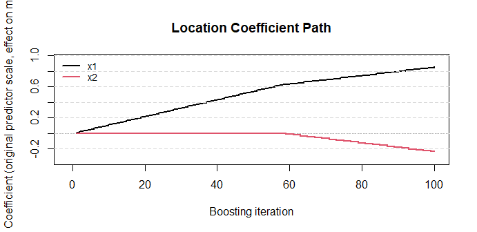

```r
plot(
  fit,
  type = "path",
  submodel = "mu",
  top_n = 8,
  scale = "original"
)
```

and for the scale predictor:

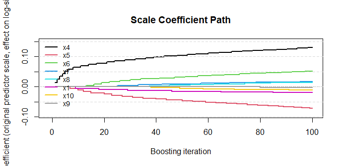

```r
plot(
  fit,
  type = "path",
  submodel = "sigma",
  top_n = 8,
  scale = "original"
)
```

The plots show how the estimated effects evolve as boosting progresses.

The `scale` argument controls whether effects are displayed on the standardized training scale or transformed back to the original predictor scale.

Selection frequencies can be visualized with

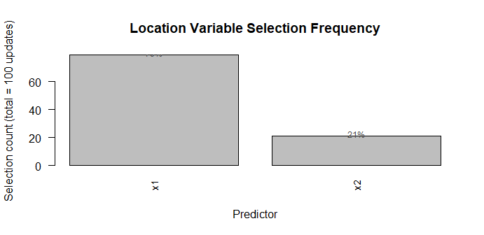

```r
plot(
  fit,
  type = "frequency",
  submodel = "mu",
  top_n = 8
)
```

and

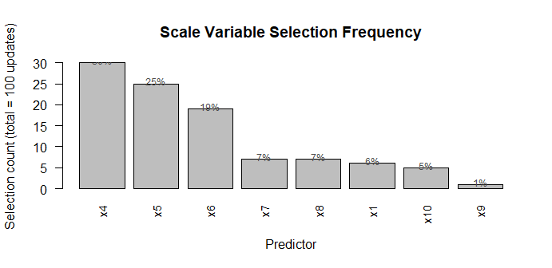

```r
plot(
  fit,
  type = "frequency",
  submodel = "sigma",
  top_n = 8
)
```

The selection frequency records how often a predictor has been selected during the boosting procedure. Predictors selected frequently are therefore favored by the component-wise fitting procedure.

This is particularly useful for models with many candidate predictors: early stopping can prevent weak variables from entering the model at all, while repeatedly selected variables accumulate larger effects.

The plotting methods require the boosting path to be retained, which is the default behavior.

# Early Stopping

The stopping iteration is the main regularization parameter in component-wise boosting.

A small number of iterations produces a strongly regularized model. As more iterations are added, additional effects can enter the model and previously selected effects can be refined.

Simply choosing a large `mstop` based on training performance is generally not appropriate because training negative log-likelihood tends to improve as the model becomes more complex.

Instead, the stopping iteration should ideally be selected using out-of-sample predictive performance.

## Patience-Based Early Stopping

`asp26boost` provides an internal validation-based early-stopping mechanism through the `patience` argument.

For example:

```r
fit_es <- boost_gaussian(
  X = sample_data[, -1],
  Z = sample_data[, -1],
  y = sample_data$y,
  mstop = 1000,
  nu_mu = 0.05,
  nu_sigma = 0.05,
  patience = 25,
  validation_split = 0.2
)
```

Here, 20% of the training observations are used as a validation sample. Boosting continues while validation risk improves. If the validation risk does not improve for 25 consecutive iterations, the search is stopped.

The best stopping point is subsequently used to refit the model on the complete dataset.

This separates the **search for the stopping iteration** from the final model fit: the final model uses all available observations rather than only the training portion of the early-stopping split.

`patience` is therefore useful when an automatically determined stopping iteration is desired without explicitly specifying a cross-validation procedure.

# Cross-Validation

An alternative is to select the stopping iteration using $k$-fold cross-validation.

`cv_boost_gaussian()` evaluates the predictive negative log-likelihood over a sequence of boosting iterations.

```r
cv_fit <- cv_boost_gaussian(
  X = sample_data[, -1],
  Z = sample_data[, -1],
  y = sample_data$y,
  k = 5,
  mstop = 500,
  nu_mu = 0.05,
  nu_sigma = 0.05,
  method = "cyclic",
  learner = "linear",
  seed = 27092001
)
```

For a Gaussian model, the validation criterion is the mean negative log-likelihood

$$\hat{\rho}_v(m)
=
\frac{1}{n_v}
\sum_{i \in v}
\left[
\log(\hat{\sigma}_i^{(m)})
+
\frac{(y_i-\hat{\mu}_i^{(m)})^2}
{2(\hat{\sigma}_i^{(m)})^2}
\right].$$

Lower values indicate better predictive performance.

The cross-validation procedure fits the complete boosting path for each fold. The resulting path can therefore be evaluated at every stopping iteration up to the supplied maximum.

Inspect the resulting object with:

```r
cv_fit
>
> Call:
> cv_boost_gaussian(X = sample_data[, -1], Z = sample_data[, -1],
>     y = sample_data$y, k = 5, mstop = 500, nu_mu = 0.05, nu_sigma = 0.05,
>     method = "cyclic", seed = 27092001, learner = "linear")
>
> Optimal mstop: 461
> Selected variables (location):
> [1] "x1"  "x2"  "x3"  "x10" "x6"  "x8"  "x7"  "x9"  "x5"
> Selected variables (scale):
> [1] "x4"  "x5"  "x1"  "x6"  "x7"  "x8"  "x10" "x9"  "x2"
```

and

```r
summary(cv_fit)
>
> Call:
> cv_boost_gaussian(X = sample_data[, -1], Z = sample_data[, -1],
>     y = sample_data$y, k = 5, mstop = 500, nu_mu = 0.05, nu_sigma = 0.05,
>     method = "cyclic", seed = 27092001, learner = "linear")
>
> Optimal mstop: 461
>
> Residuals:
>     Min.  1st Qu.   Median     Mean  3rd Qu.     Max.
> -6.72501 -0.54241 -0.02167  0.02200  0.58494  7.84366
>
> Coefficients (location):
>           x1           x2           x3           x4           x5           x6
>  1.983055699 -1.482216837  0.991708058  0.000000000 -0.001210494  0.013324598
>           x7           x8           x9          x10
> -0.010329831  0.007827757 -0.009984439  0.033560244
>
> Coefficients (scale):
>          x1          x2          x3          x4          x5          x6
>  0.01815440 -0.01544094  0.00000000  0.45065884 -0.38505808  0.24104706
>          x7          x8          x9         x10
>  0.01321935  0.01733950  0.01489235  0.03164023
```

The selected stopping iteration is the iteration with the lowest averaged validation risk across folds.

# Visualizing the Cross-Validation Curve

The cross-validation results can be visualized directly:

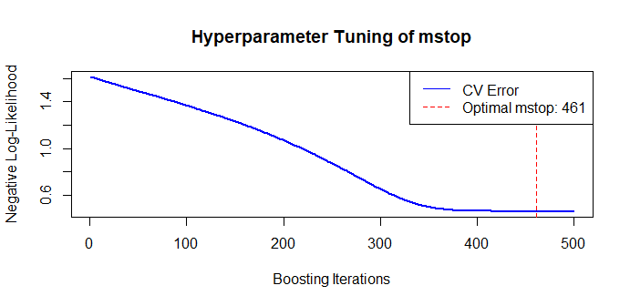

```r
plot(cv_fit)
```

The curve shows the estimated validation negative log-likelihood as a function of the boosting iteration.

The selected stopping iteration corresponds to the minimum of the estimated validation risk.

This visualization is useful for diagnosing the regularization behavior of the model. Typically, validation risk initially decreases as useful effects are added and eventually levels off or increases as additional complexity begins to hurt predictive performance.

# Prediction from a Cross-Validated Model

The cross-validated object contains a final model refitted on the complete dataset at the selected stopping iteration.

Predictions can therefore be generated directly:

```r
predict(cv_fit)
>   [1]  1.33506060 -1.54759991 -4.39459997 -0.57844571 -3.88075381 -3.98146298
>   [7]  1.70017795  2.04364469  0.80234358 -3.16284129 -6.59477775  1.87246979
>  [13]  4.24282420 -2.58938253 -4.34525718 -0.62073252 -3.66875778  0.57221411
>  [19]  1.02750375  3.68882182 -4.01607473  0.61009643 -0.87380136 -2.04089395
>  [25]  1.72814005  1.08470877 -0.98791676  2.89227879 -3.93249108 -4.55026389
>  [31]  0.29316529 -2.20215288  0.88225537  1.81543032  1.08473525 -1.67152293
>  [37]  2.81979681 -3.43016025  7.43004526  1.12738727  3.44659437  1.52316258
>  [43] -0.36388878 -0.04382494 -0.11320244 -0.80165427 -0.95775673 -1.20574835
>  [49]  2.17415465 -0.73460844 -4.40729867  1.22067927  4.93476526  3.26291810
>  [55]  5.23696794 -1.66239517 -0.90844306  1.49900942 -0.55083286  2.96842221
>  [61] -7.54403742  3.25878506 -0.55672619 -3.55335122 -3.01502197 -3.96080559
>  [67]  3.50850233 -2.28192969 -0.62568131 -0.98632941 -2.50764170  1.04823616
>  [73]  0.08279252 -3.75331337 -0.48813179  2.61462926 -0.50235892  1.79318606
>  [79] -3.87849977 -6.95831498  2.99835229  0.11227562  1.35893469 -4.45105588
>  [85]  0.91090608  1.68574198  3.03718695  6.81375104  0.94130806  0.42540508
>  [91] -2.08564469 -3.53421992 -2.85737546  0.65766236 -2.75679852 -2.15207516
>  [97]  0.60752078 -3.70700163  0.08945735 -2.31189141
>  [ reached 'max' / getOption("max.print") -- omitted 900 entries ]
```

For new observations:

```r
predict(
  cv_fit,
  newdata_X = new_data,
  newdata_Z = new_data
)
> [1]  1.3350606 -1.5475999 -4.3946000 -0.5784457 -3.8807538
```

The final predictions are based on the model fitted using the cross-validation-selected stopping iteration.

# Hyperparameter Grid Search

In addition to the stopping iteration, the learning rates and base-learner type can be treated as tuning parameters.

`cv_boost_grid()` evaluates combinations of the supplied candidate values.

```r
grid_fit <- cv_boost_grid(
  X = sample_data[, -1],
  Z = sample_data[, -1],
  y = sample_data$y,
  k = 5,
  mstop_grid = c(50, 100, 200),
  nu_mu_grid = c(0.01, 0.05, 0.1),
  nu_sigma_grid = c(0.01, 0.05, 0.1),
  seed = 27092001
)
```

The resulting object can be inspected with:

```r
grid_fit
>
> Call:
> cv_boost_grid(X = sample_data[, -1], Z = sample_data[, -1], y = sample_data$y,
>     k = 5, mstop_grid = c(50, 100, 200), nu_mu_grid = c(0.01,
>         0.05, 0.1), nu_sigma_grid = c(0.01, 0.05, 0.1), seed = 27092001)
>
> Best combination:
>    mstop nu_mu nu_sigma learner  cv_error optimal_stop
> 27   200   0.1      0.1  linear 0.4641155          200
```

The grid search evaluates the Cartesian product of the supplied candidate hyperparameters. Consequently, the computational cost can increase substantially when many candidate values are supplied.

For practical applications, it is therefore advisable to first choose a reasonable range of learning rates and then use cross-validation to identify a suitable combination.

# Choosing a Model Configuration

The main modeling choices can be summarized as follows.

| Goal | Recommended configuration |
| --- | --- |
| Approximately linear effects | `learner = "linear"` |
| Nonlinear effects expected | `learner = "spline"` |
| Functional form unknown | `learner = "auto"` |
| Standard distributional boosting | `method = "cyclic"` |
| Select one best parameter update at a time | `method = "noncyclic"` |
| Fast automatic stopping | `patience` |
| More robust stopping selection | `cv_boost_gaussian()` |
| Tune several hyperparameters | `cv_boost_grid()` |

For most applications, a sensible starting point is a cyclic model with a relatively small learning rate and cross-validation-based stopping.

For example:

```r
fit <- cv_boost_gaussian(
  X = sample_data[, -1],
  Z = sample_data[, -1],
  y = y,
  k = 5,
  mstop = 500,
  nu_mu = 0.05,
  nu_sigma = 0.05,
  method = "cyclic",
  learner = "linear",
  seed = 123
)
```

If nonlinear effects are plausible, replacing `learner = "linear"` by `learner = "spline"` is a natural extension.

# Reproducibility

Functions involving random resampling accept an explicit `seed` argument. Providing a seed makes the fold assignment or validation split reproducible on the same R and package versions.

For example:

```r
cv_fit <- cv_boost_gaussian(
  X = sample_data[, -1],
  Z = sample_data[, -1],
  y = y,
  k = 5,
  mstop = 500,
  nu_mu = 0.05,
  nu_sigma = 0.05,
  seed = 27092001
)
```

For fully reproducible analyses, the R version and package version should also be recorded.

# Summary

This vignette demonstrated the main workflow for Gaussian component-wise boosting with `asp26boost`.

The key steps are:

1. construct predictor matrices for the location and scale submodels;
2. fit a Gaussian location-scale boosting model with `boost_gaussian()`;
3. choose between linear and spline base learners;
4. choose a cyclic or noncyclic update schedule;
5. inspect coefficient paths and variable-selection frequencies;
6. control model complexity through early stopping;
7. use cross-validation to select the stopping iteration; and
8. optionally use `cv_boost_grid()` to tune several hyperparameters.

The central feature of the approach is that the conditional distribution is modeled jointly. Both the location and scale can depend on covariates, while component-wise updates and early stopping provide regularization and implicit variable selection.

For applications with many candidate predictors, this combination makes component-wise boosting particularly attractive: the algorithm can construct sparse distributional models without requiring an unregularized estimation of all coefficients simultaneously.